# Reading an FEC Candidate Filing

Where a campaign’s money comes from, and where the record stops naming it

Democracy’s Data

Last updated September 13, 2026 at 10:53a EDT

Everybody knows where campaign money comes from. It comes from special interests, from lobbyists, from political action committees with names nobody recognises. That is the sentence a citizen hears every election year, usually attached to a number with a lot of zeros in it.

The sentence is checkable, because every federal campaign has to write the answer down. **So where does a candidate’s money actually come from?** Not in the aggregate, and not in a slogan, but on the form a treasurer signs.

The answer decides what a reform would have to change. If organised money is buying elections, the problem is who wins. If it is buying something else, the problem is what happens after somebody has already won, and the two need different remedies.

## The test

The evidence is one filing, read end to end, and then all 3,856 of them at once. The file is the summary the Federal Election Commission publishes for every candidate’s committee each election cycle — a cycle being the two years that end with a federal election, here 2023–24. It is downloadable from the FEC’s bulk-data page at https://www.fec.gov/data/browse-data/?tab=bulk-data under “All candidates” (`weball24` for this cycle): one row per candidate who filed, covering committee activity through 31 December 2024.

A mandatory filing is the right instrument for this question, and for a narrow reason. It is a complete count rather than a sample, so an incumbent’s receipts and a challenger’s can be set side by side with no sampling assumption in between. The four source categories mean the same thing in both rows, because the same form imposed them on both. What a disclosure filing is, who writes it, and why disclosure is not the same as audit is the subject of this cluster’s campaign-finance chapter.

One row is one candidate’s committee for the whole cycle — the filer is always a committee, the campaign organisation with a treasurer that raises and spends on the candidate’s behalf, never the candidate personally. It holds everything raised, and a breakdown by source: individual people, political action committees (PACs, through which a company, union or interest group pools its members’ contributions and passes them to candidates), the party, and the candidate’s own pocket.

| Candidate | State | I/C/O | Total receipts | From individuals | From PACs |
| --- | --- | --- | --- | --- | --- |
| TRONE, DAVID | MD | I | $63,833,137 | $853,812 | $5,000 |
| SCHIFF, ADAM | CA | I | $48,149,197 | $45,110,629 | $1,015,453 |
| ROSEN, JACKY | NV | I | $43,915,245 | $33,769,625 | $2,574,528 |

The `ici` column beside each name is the narrowest field in the file. It records whether the candidate was an **I**ncumbent, a **C**hallenger, or running for an **O**pen seat.

## The data

The Commission publishes the file with the fields on each line separated by the `|` character and no header row to name them. Here is one complete record, laid out one field per row so it fits the page. Nothing else is changed.

| Field | Value |
| --- | --- |
| 1 | P40011082 |
| 2 | RAMASWAMY, VIVEK |
| 3 | C |
| 4 | 2 |
| 5 | REP |
| 6 | 66197196.43 |
| 7 | 0 |
| 8 | 66197196.43 |
| 9 | 0 |
| 10 | 0 |
| 11 | 0 |
| 12 | 25875270.05 |
| 13 | 28880000 |
| 14 | 0 |
| 15 | 24018188 |
| 16 | 0 |
| 17 | 0 |
| 18 | 11206974.33 |
| 19 | 00 |
| 20 | 00 |
| 21 | (empty) |
| 22 | (empty) |
| 23 | (empty) |
| 24 | (empty) |
| 25 | (empty) |
| 26 | 13750 |
| 27 | 0 |
| 28 | 09/30/2024 |
| 29 | 113233.27 |
| 30 | 950 |

That is one line of 3,856, carrying 30 fields and no names for any of them. The values sit in an order the file never states. The Commission publishes that order in a separate document, on a different page of its website.[^1] Shift the layout by one and every dollar in this brief lands in the wrong category, with no error and no warning.

A few of the positions, once that separate document is consulted:

| Position | Value | Becomes | What it is |
| --- | --- | --- | --- |
| 1 | P40011082 | cand_id | the Commission’s permanent ID for this candidate |
| 2 | RAMASWAMY, VIVEK | cand_name | the candidate’s name, as filed |
| 3 | C | ici | incumbent, challenger, or open seat — one letter |
| 6 | 66197196.43 | ttl_receipts | everything the committee raised this cycle |
| 12 | 25875270.05 | cand_contrib | money the candidate gave their own campaign |
| 13 | 28880000 | cand_loans | money the candidate lent it, which is not the same thing |
| 18 | 11206974.33 | indiv_contrib | money from individual people |
| 26 | 13750 | pac_contrib | money from political action committees |

| Candidate | Office | I/C/O | Total receipts | From individuals | From PACs | Own money |
| --- | --- | --- | --- | --- | --- | --- |
| RAMASWAMY, VIVEK | President | C | $66,197,196 | $11,206,974 | $13,750 | $54,755,270 |

Cleaned, the same candidate is a row you can read, and four things happened to get there.

**Names were attached, and then checked.** Each of the 30 positions was given the name the Commission’s layout assigns it, and the count was checked first: had any other number of fields arrived, nothing below would have been computed. That check is the whole defence against the layout changing in a future cycle.

**Two columns were invented.** Neither `office` nor `own money` is in the download. Office is the first character of the candidate ID, so P40011082 is a candidate for President because it begins with P. Own money is `cand_contrib`, what the candidate gave their campaign, added to `cand_loans`, what they lent it. That addition is a definition rather than a measurement, and a reader who thinks a loan is not a gift is entitled to a different column.

**Nothing was repaired.** 3,856 rows went in and 3,856 came out. Candidates who appear more than once were not merged, the 60 rows whose incumbency letter is blank were not filled, and the 986 candidates who reported raising nothing at all were not removed. Each of those is a defect somebody would ordinarily clean, and each is evidence about how federal campaign finance is recorded.

> **Before you read on, commit to a number.** Among the 1,318 serious House campaigns in this file, meaning everyone who raised more than fifty thousand dollars, political action committees supply 37.6% of the median incumbent’s receipts. **What percentage do they supply the median open-seat candidate?** That is the race with no incumbent to unseat and a result genuinely in doubt. Write a number down, above or below 37.6%, before you read on.

## What it says about democracy

Start with the whole House, where there are enough candidates for a pattern to exist.

| Quantity | Value |
| --- | --- |
| House candidates | 3,073 |
| Median total raised | $22,583 |
| Mean total raised | $782,177 |
| Mean ÷ median | 34.6× |

The median House candidate — the one in the middle, with as many candidates above as below — raised $22,583. The average, every total added up and divided by the number of candidates, is $782,177, which is 35 times more. Whenever a mean sits that far above a median, a few cases are carrying nearly everything and the average has stopped describing anybody. So every figure below is a median or a share, never an average.

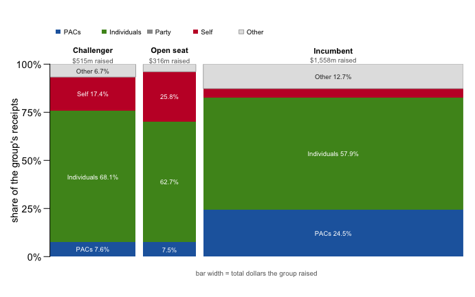

**Figure 1. Individuals pay for most of every kind of campaign; what differs is what covers the rest.** Serious House campaigns only. A mosaic is the right form because the question has two parts at once. Bar height is composition and bar width is total dollars raised, so the area of a coloured block is real money rather than a share of a share. The PAC block in the incumbent bar is $382m against $39m in the challenger bar. “Other” is receipts that are none of the four named sources, mostly transfers from the candidate’s own other committees, which is why it is largest for incumbents.

So the slogan is wrong in its first clause. **Individuals supply the majority of every group’s money**, 57.9% for incumbents, 68.1% for challengers and 62.7% for open-seat candidates. Organised money is the minority partner everywhere in this file. That is the pattern Ansolabehere, de Figueiredo and Snyder found across decades of these filings, and the reason they asked why there is so *little* money in American politics rather than so much: most of it is given by individuals, in amounts that look more like a consumer’s purchase than an investor’s bet.[^2]

Where it is not wrong is in the pattern. Look at what fills the gap when PACs do not.

| Quantity | Value |
| --- | --- |
| Candidates raising more than $100,000 | 1,421 |
| Of those, funding more than half of it themselves | 225 |
| Share | 15.8% |

About one in six serious candidates paid for more than half of their own campaign. 17.4% of all challenger money and 25.8% of all open-seat money comes from the candidate’s own pocket, against 4.8% for incumbents. That is a barrier to entry with a dollar figure attached.

Now the gap everyone quotes.

| Status | Candidates | Median raised |
| --- | --- | --- |
| Challenger | 1,718 | $9,107 |
| Open seat | 764 | $19,272 |
| Incumbent | 562 | $1,537,105 |

The median incumbent raised $1,537,105 and the median challenger $9,107, a ratio of about **169 to one**. On its own that settles nothing. Money might make incumbents safe, or safe incumbents might attract money, and both stories predict exactly this table.

The file will break the tie without any research design. Ask not *how much* each group raises, but **what share of it comes from PACs**. An open-seat race is the most competitive kind there is: no incumbent, a result genuinely uncertain, maximum leverage for anyone trying to influence who wins. Money spent to decide an election should go there.

| Status | Candidates | Median PAC share of receipts |
| --- | --- | --- |
| Challenger | 545 | 1.1% |
| Open seat | 319 | 1.4% |
| Incumbent | 454 | 37.6% |

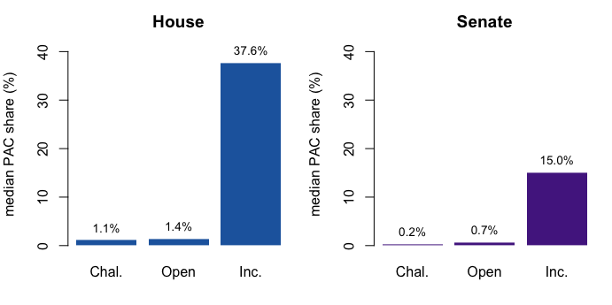

Most readers write down a number near the incumbent’s, and many write down a larger one, because that is where money would go if money were trying to decide elections. The open-seat figure is 1.4%, essentially the same as a challenger’s 1.1%. **PAC money is not sorted by competitiveness. It is sorted by who currently holds the seat.**

That is enough to break the tie. Whatever organised money is buying, it is not the outcome of an election, because it is demonstrably not going where outcomes are decided. Fouirnaies and Hall (2014) reach the same conclusion by a stronger route, comparing candidates who barely won against candidates who barely lost — two groups alike in everything but the office — and find that holding the seat itself raises a candidate’s share of contributions, with the rise concentrated among donors who want access to whoever wins rather than a particular winner.[^3]

There is one more thing to say about the biggest block in Figure 1. **The largest source is the least identified one.** Federal law requires a committee to itemise a contributor by name, address, occupation and employer only once that person’s giving passes $200. Below that line the money is reported as a lump sum. That threshold is set by statute and the Commission’s rules rather than found by this brief.[^4] So the 57.9% marked “Individuals” in the incumbent bar is a sum over two populations, and the public record names only one of them.

## What this brief cannot tell you

**It cannot tell you who won.** The FEC’s layout has a general-election-result column and it is blank in every row. The Commission regulates finance, not elections, and no national election administrator exists to supply the answer.

| Question | Answerable from this file |
| --- | --- |
| Who did each candidate raise money from? | Yes |
| How much did they spend? | Yes |
| Did they win? | No — the column is empty in the source |

So the most obvious question in the subject, whether the candidate who raises more wins, cannot be asked of this file without going to fifty-one separate state authorities. That is a fact about how the American state keeps its books rather than a gap in this dataset.

**It cannot be summed.** Adding the receipts column gives $6.85 billion for the cycle, of which roughly $1.57 billion does not exist. It is the same money counted twice, mostly Biden’s presidential committee, which became Harris’s in July 2024 and is reported in full against both candidate IDs.

**It cannot name small donors.** The itemisation threshold above means the individual-contribution column mixes named givers with an anonymous remainder, and this summary file reports only the sum.

**It covers candidate committees only.** Independent expenditures (money spent for or against a candidate by a group the candidate does not control), party spending and undisclosed money are somewhere else or nowhere. Since *Citizens United v. FEC* (2010) a large share of what is spent on a competitive race never passes through the candidate’s hands.[^5]

## What you should have learned

- Individuals, not organised committees, supply most of every kind of campaign’s money: 57.9% for incumbents, 68.1% for challengers, 62.7% for open-seat candidates.
- PAC money is allocated by office held, not by contest. It is 37.6% of a typical serious House incumbent’s receipts and 1.4% of an open-seat candidate’s, and the open seat is the most competitive race there is.
- Candidates without organised money pay for themselves: 17.4% of all challenger money is the candidate’s own, against 4.8% for incumbents, and 225 of the 1,421 candidates raising over $100,000 covered more than half their own campaign.
- The file is authoritative and incomplete at once. It records every federal candidate committee and no election result, and summing its receipts column overstates the cycle by about $1.57 billion.
- The biggest category is the least itemised: individual giving under $200 in a cycle is reported as a total with no donor named.

## Extensions

None of these is answered above, and every one can be answered by sorting or grouping in a spreadsheet.

- `fec_candidates_2024.csv` has `ttl_receipts` for every candidate. Compute the mean and the median, and note how far apart they are. Which one belongs in a headline about the cost of a seat?
- Sort `fec_candidates_2024.csv` by `self_funding` and take the top fifty. Compare their `ttl_receipts` against the median for their `office`. Does buying your own campaign buy a big one?
- Group `fec_candidates_2024.csv` by `ici` and compute `pac_contrib` divided by `ttl_receipts`. Then do the same for `indiv_contrib`. Which source separates the three groups more sharply?
- Group by `office` and `party` and compare typical `ttl_receipts`. Where in this file is money least evenly spread?

Two stretch ideas go past the spreadsheet. Download the previous cycle’s “All Candidates” file from the same address and check whether the PAC pattern in Figure 2 holds in a year with a different result. And take one candidate’s `cand_id`, look up their itemised receipts in the FEC’s individual-contributions file, and see how much of their individual total the named donors account for.

## Sources

**Data**

- Federal Election Commission, bulk download, “All Candidates” file for the 2023–24 cycle, covering every candidate committee’s activity through 31 December 2024. https://www.fec.gov/data/browse-data/?tab=bulk-data
- Federal Election Commission, “All candidates file description,” the layout that names the file’s 30 positions. https://www.fec.gov/campaign-finance-data/all-candidates-file-description/

**The rule behind the form**

- Itemisation threshold: a committee reports a contributor’s name, address, occupation and employer only when that person’s contributions exceed $200 in the calendar year or election cycle. 52 U.S.C. §30104(b)(3)(A) and 11 CFR 104.3(a)(4)(i). https://www.law.cornell.edu/uscode/text/52/30104 https://www.ecfr.gov/current/title-11/chapter-I/subchapter-A/part-104/section-104.3

**Academic literature**

- Ansolabehere, S., de Figueiredo, J. M. and Snyder, J. M. Jr. (2003). “Why Is There So Little Money in U.S. Politics?” *Journal of Economic Perspectives* 17(1): 105–130. https://www.aeaweb.org/articles?id=10.1257/089533003321164976
- Fouirnaies, A. and Hall, A. B. (2014). “The Financial Incumbency Advantage: Causes and Consequences.” *Journal of Politics* 76(3): 711–724. doi:10.1017/S0022381614000139.
- *Citizens United v. Federal Election Commission*, 558 U.S. 310 (2010). https://www.law.cornell.edu/supremecourt/text/08-205

**The data itself**

Every figure above is drawn from this table. It is plain CSV, it opens in a spreadsheet, and it is yours to take further.

`fec_candidates_2024.csv`

Rebuild this data yourself, with an AI assistant

```
I want to rebuild a public dataset from its original source, without any
starting files. Please do the following and show your work.

THE SOURCE. Federal Election Commission, bulk download "All Candidates"
file for the 2024 cycle:
https://www.fec.gov/files/bulk-downloads/2024/weball24.zip
No account or key is needed. The zip is small — about 170 KB — and
holds one pipe-delimited text file with NO header row; the FEC
publishes the column layout separately as the "all candidates file
description", thirty columns. Each row is one candidate who filed with
the FEC for the 2023-24 election cycle, with their committee's
receipts, spending, and where the receipts came from.

WHAT TO BUILD.
1. A table of every candidate: name, office (the first letter of the
   candidate ID is H, S or P), state, party, total receipts, total
   spending, and the receipts broken out by source — individuals,
   PACs, the party, and the candidate's own pocket.
2. A hunt for duplicated money. Some people appear under two candidate
   IDs — one for each office they pursued — with the SAME committee
   totals attached to both. Find every receipts total above a million
   dollars that appears on more than one row. These duplicates are
   real records, not errors to delete; the point is to know they are
   there before summing anything.

CHECK YOUR WORK. The copy this book used was downloaded in August 2026.
If your rebuild matches it, you should find:
- 3,856 candidate rows
- the largest receipts figure, $1,175,189,365.41, appears on two rows:
  Kamala Harris's and Joe Biden's presidential IDs carry the same
  committee's money
- Ruben Gallego's House and Senate IDs both carry $64,657,199.96
- the win/loss column in the layout is empty on every row
The FEC keeps amending closed cycles as corrections arrive; small
differences mean the file was revised, not that you made an error.
```

[^1]: The layout: https://www.fec.gov/campaign-finance-data/all-candidates-file-description/.
[^2]: Stephen Ansolabehere, John M. de Figueiredo and James M. Snyder Jr., “Why Is There So Little Money in U.S. Politics?” *Journal of Economic Perspectives* 17, no. 1 (2003): 105–130, https://www.aeaweb.org/articles?id=10.1257/089533003321164976.
[^3]: Alexander Fouirnaies and Andrew B. Hall, “The Financial Incumbency Advantage: Causes and Consequences,” *Journal of Politics* 76, no. 3 (2014): 711–724, doi:10.1017/S0022381614000139.
[^4]: 52 U.S.C. §30104(b)(3)(A) (https://www.law.cornell.edu/uscode/text/52/30104) and 11 CFR 104.3(a)(4)(i) (https://www.ecfr.gov/current/title-11/chapter-I/subchapter-A/part-104/section-104.3).
[^5]: *Citizens United v. Federal Election Commission*, 558 U.S. 310 (2010): https://www.law.cornell.edu/supremecourt/text/08-205.